# WIP paper for mapping seagrass carbon using remote sensing

Lee, Chengfa Benjamin

4 November 2026 (last updated on 23 novembre 2026)

This is a work in progress document for an upcoming publication.

## 1 Introduction

Work in progress

## 2 Methods and Materials

### 2.1 Study sites

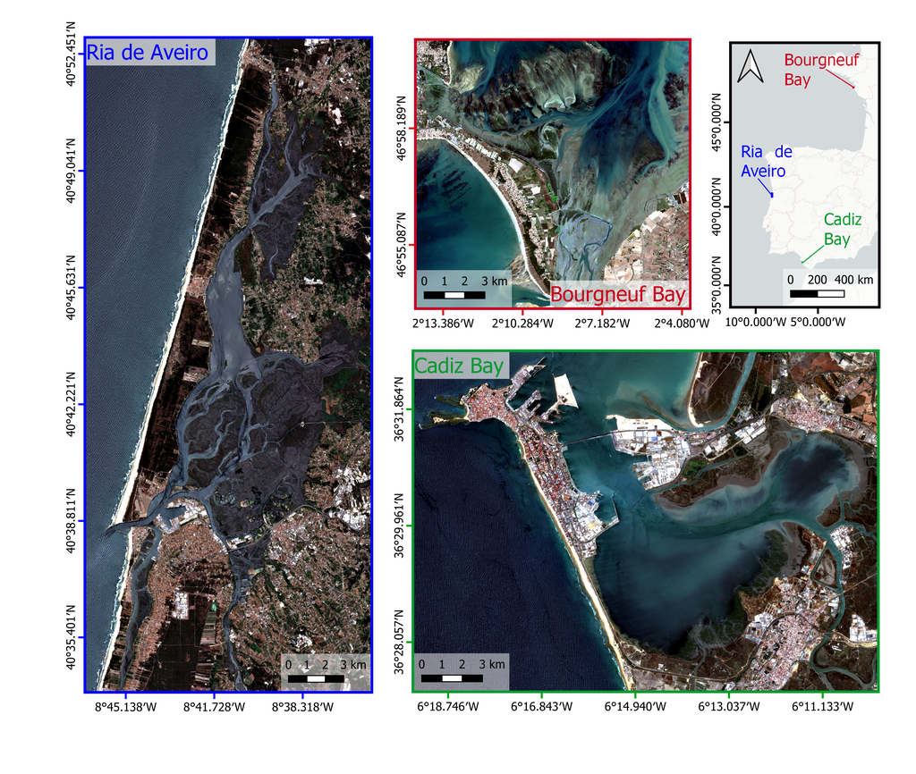

Figure 1: Overview map of the three study sites. Basemap: CartoDB Light No Labels.

#### 2.1.1 Bourgneuf Bay

Bourgneuf Bay is located southeast of the Loire Estuary. It is enclosed by Noirmoutier island in the southwest and has a mouth spanning 12 km in the northwest. The bay has a semidiurnal tidal regime and a tidal height of 2 to 6 m. It spans 340 km2 in surface area, of which 100 km² is intertidal area consisting mudflats and rocky areas (Barillé et al. 2020).

Both *Zostera noltii* and *Zostera marina* are found in this site. The seagrass meadows have a predicted seagrass extent of 4.9 km² in September 2021 (Davies et al. 2024a). Seasonally, the peak meadow expansion rate occurs in July and their maximum extent is reached in September (Davies et al. 2024b). In April, the seagrass meadows decrease to an annual minimum of almost 0 km².

#### 2.1.2 Cadiz Bay

Owing to historical development in the area, Cadiz Bay comprises two basins that are connected by a narrow channel. The outer basin has an area of 70 km² and is connected to the ocean in the west. The inner basin has an area of more than 50 km², including large areas of marshes in its intertidal zone. Ninety seven percent of its intertidal zone has a muddy bottom. The Puntales channel connects both basins, and is 3.8 km long and 1.3 km wide. The tidal regime is mainly semidiurnal, with a tidal range of 1 to 4 m (Zarzuelo et al. 2017).

*Z. noltii*, *Z. marina*, and *Cymodocea nodosa* are found in this site. The seagrass meadows have a predicted seagrass extent of 2.1 km² in November 2021 (Davies et al. 2024a). Seasonally, the peak meadow expansion rate occurs in August and their maximum extent is reached in October (Davies et al. 2024b). Between June to July, the seagrass meadows decrease to an annual minimum.

#### 2.1.3 Ria de Aveiro

Ria de Aveiro is a shallow coastal lagoon that is largely shaped by human related development, including various construction works and dredging. The lagoon is about 45 km long and 8.5 km wide and connected to the sea via an artificial inlet. It has a semidiurnal tidal regime, with a tidal range of 0.6 to 3.2 m. The lagoon contains large mudflats, salt marshes, and narrow channels (Dias et al. 2021).

Both *Z. noltii* and *Z. marina* are found in this site. The seagrass meadows have a predicted seagrass extent of 3.5 km² in December 2017 (Davies et al. 2024a). Seasonally, the peak meadow expansion rate occurs in September and their maximum extent is reached in November (Davies et al. 2024b). In June, the seagrass meadows decrease to an annual minimum.

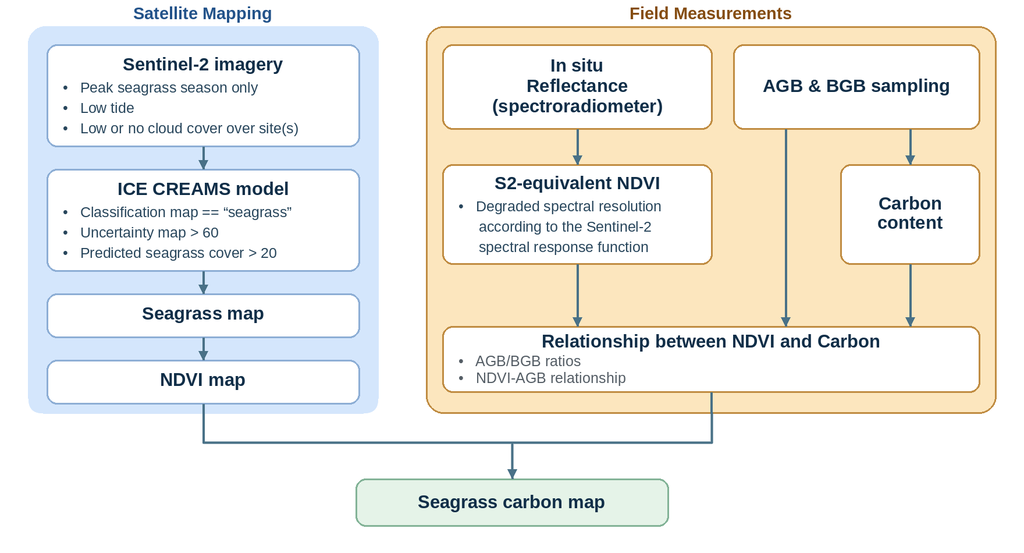

Figure 2: Study workflow.

### 2.2 Field sampling and processing

For every station, seagrass cover was visually assessed with the aid of a 50 cm by 50 cm quadrat. The location of each station was measured using an Emlid Reach RS2+ GNSS receiver with RTK corrections.

#### 2.2.1 Seagrass biomass

Sediment cores were collected using a 15 cm diameter length PVC pipe. The coring was sufficiently deep, such that all belowground biomass were collected.

The collected samples were rinsed in seawater and sieved using a 40 cm diameter stainless steel sieve with a mesh size of 1 mm to remove as much substrate as possible. The samples were then transported to back to the laboratory and preserved in a fridge.

The samples were sorted into leaf and root matter by separating the plant at the internode.

The samples were dried in an oven at 60 °C for 48 hours. After desiccation, the samples were weighed using a bench scale to obtain their dry weight.

#### 2.2.2 Seagrass carbon

The dried samples were placed in 50 ml falcon tubes with a ceramic ball of diameter 20 mm. The tubes were loaded onto the Mixer Mill MM 400 and grinded at 30 Hz at 30 seconds. If the initial grinding was insufficient, the sample was grinded again at the same intensity and period until homogeneous.

To measure the TC content in a sample, about 70g of powdered biomass was combusted at 900 °C for 8 minutes. For the IC content measurement, between 200-800 g of powdered biomass was mixed with 0.9 ml of phosphorous acid (HPO3) and combusted at 300 °C until no carbon dioxide is detected. The increased weight of sample used was to increase the IC content measurement, as about 200 g of sample produced around 2 mg of carbon while 700 g of sample yielded around 6 mg of carbon. The measurements were scaled to the unit weight of the samples based on the sample dry weight used for the measurement (Equation (1)).

$$\begin{equation}
\text{Carbon content (g per C/g)} = \frac{\text{Measured carbon (g)}}{\text{Sample dry weight (g)}} \tag{1}
\end{equation}$$

A subset of the samples were used to test for possible water content in the sample. These samples were placed in a 105 °C oven and measured after 2 hours and 3 hours. Any difference in weight was attributed to water content loss (Equation (2)). Since only a subset was used in this test, the results were averaged and used to correct for the sample dry weight in Equation (1).

$$\begin{equation}
\text{Corrected dry weight} = \frac{\text{Pre-oven dry weight}}{\text{Post-oven dry weight}} \times \text{Subsampled dry weight} \tag{2}
\end{equation}$$

The [difference between the TC and IC content is the total organic carbon content (TOC)](https://www.shimadzu.com/an/apl/24168/index.html) (Equation (3)). The TOC is the mass of organic carbon in a unit mass of a dry weight sample.

$$\begin{equation}
\text{TOC (g C/g)} = \text{TC} - \text{TIC} \tag{3}
\end{equation}$$

#### 2.2.3 Radiometric measurements

For select stations, in situ spectroradiometric measurements were measured using an ASD FieldSpec HandHeld 2. The ASD was calibrated using a white reference panel before each measurement to account for possible ambient light changes and instrumental noise. Twenty readings were measured per station and averaged to obtain an averaged spectrum. The averaged hyperspectral signature was smoothed with a Savitzky-Golay filter using the sgolayfilt() function (signal developers 2023) at third order and length of 11. While this means that the first and last five wavelengths would be dropped, given the spectroradiometer’s full wavelength range of 325 nm to 1075 nm and the final working range of 400 nm to 900 nm, these affected wavelengths will be filtered out anyway and thus irrelevant here.

[figure not shown]

Figure 3: Spectroradiometric measurements of seagrasses at Cadiz Bay (A). After these measurements were taken, the measured seagrass area was then extracted with a 15 cm diameter PVC pipe (B). This ensures that the collected seagrass biomass and their corresponding seagrass cover is directly related to the aforementioned measurements (C). The samples were then cleaned and sorted into aboveground biomass containing leaves (D) and belowground biomass containing roots and rhizomes (E).

Post-smoothing, only the wavelengths from 400 nm to 900 nm were retained and a min-max standardisation was performed.

For comparison with the Sentinel 2 imagery, the wavelengths were degraded to the Sentinel 2 bands based on the spectral response function of Sentinel 2A provided in “COPE-GSEG-EOPG-TN-15-0007 - Sentinel-2 Spectral Response Functions 2022 - 3.2” (*Sentinel-2 Spectral Response Functions* (version 3.2) 2023). From the degraded bands, the Normalised Difference Vegetation Index (NDVI) was derived using Equation (4):

$$\begin{equation}
\text{NDVI} = \frac{R(\lambda_{\text{NIR}}) - R(\lambda_{\text{Red}})}{R(\lambda_{\text{NIR}}) + R(\lambda_{\text{Red}})} \tag{4}
\end{equation}$$

#### 2.2.4 Establishing relationships between reflectance, biomass and carbon

The relationships between the spectroradiometer reflectance and aboveground biomass were first investigated to develop an algorithm to predict aboveground biomass from reflectance. Next, the site-specific ratio between the aboveground and belowground biomass were derived to predict belowground biomass from aboveground biomass. Finally, the site-specific carbon content for both the above- and belowground biomass was investigated in order to predict carbon stock from the relevant biomass data.

#### 2.2.5 Satellite data and processing

Low tide Sentinel-2 Level-2A Surface reflectance *R(λ)* images with few clouds or cloud shadows over the study sites were identified and downloaded.

The images were then processed with the two step ICE CREAMS model approach. Firstly, an intertidal mask to produce an intertidal classification map, a seagrass cover map and a classification uncertainty map. Pixels that do not fulfil all three conditions were masked:

1. Classified as seagrass in the ICE CREAMS classification map
2. Have a classification certainty of at least 60 %
3. Have a seagrass percent cover of at least 20%

Next, the seagrass cumulative extent was calculated by summing the masked seagrass cover map. Since each pixel of the ICE CREAMS output maps is 100 m2, therefore each unit in percent cover of the pixel would directly translate into a unit area of the seagrass extent in square metres (Davies et al. 2024b). Since the current version of ICE CREAMS no longer provides an NDVI map as a default output, an NDVI image was derived from the masked Sentinel 2 Level 2A *R(λ)* images using Equation (4).

#### 2.2.7 Validation and error propagation

WIP.

## 3 Results

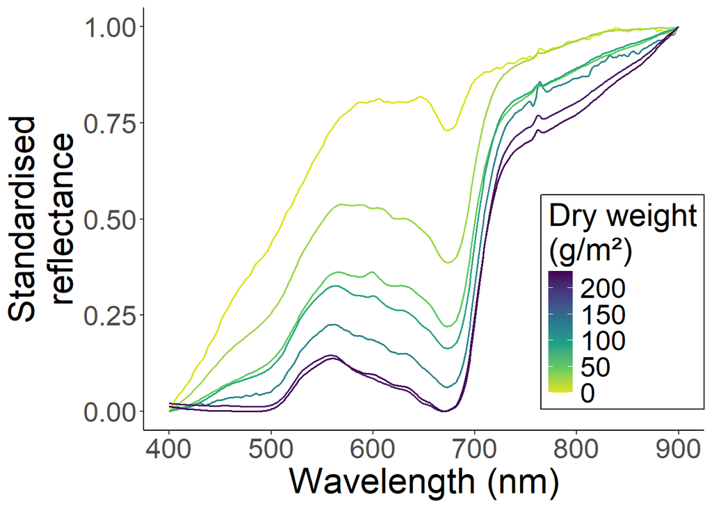

Figure 4: Min-max standardised values of spectroradiometer measurements to the leaf dry weight.

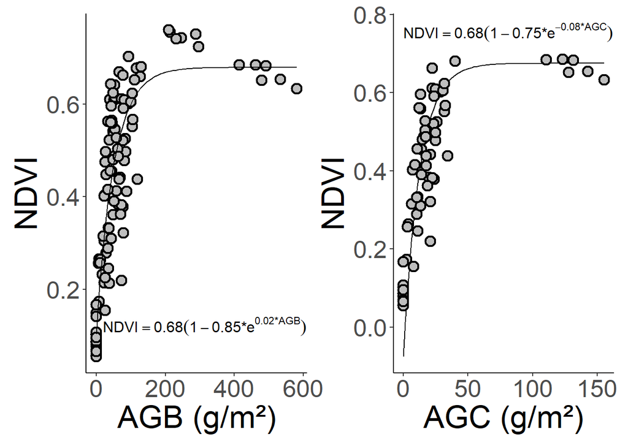

Figure 5: Relationship between the spectroradiometer-derived NDVI values and the seagrass aboveground biomass (AGB) (left) and the spectroradiometer-derived NDVI values and the seagrass aboveground carbon (AGC) (right).

This is the equation used for the estimation of aboveground carbon from NDVI:

$$\begin{equation}
\text{AGC} = 0.35 * \mathrm{e}^{8.2*\text{NDVI}} \tag{5}
\end{equation}$$

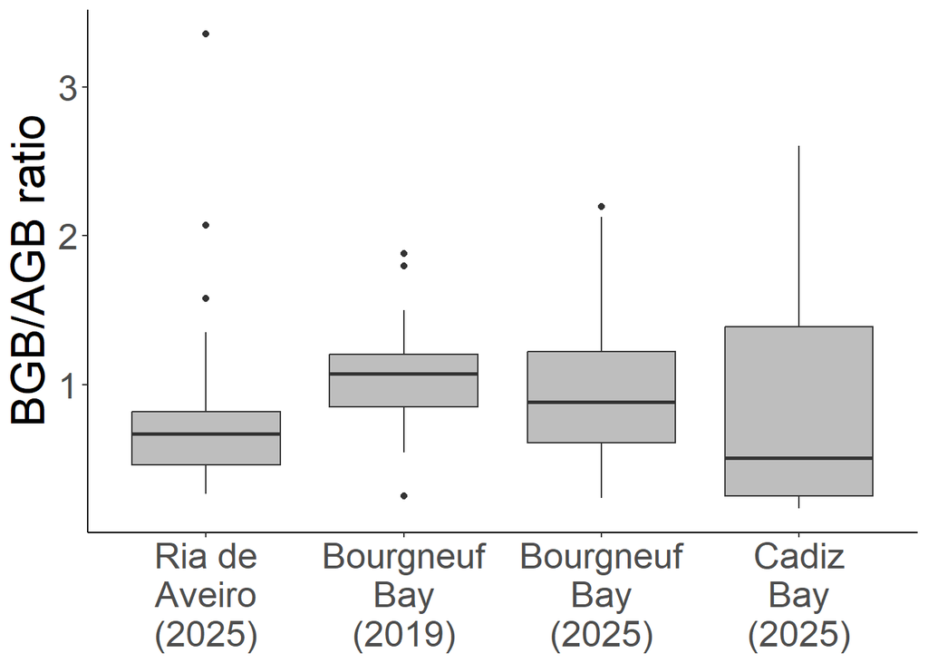

Figure 6: Ratio of seagrass belowground biomass (BGB) to aboveground biomass (AGB) across the different sites and years.

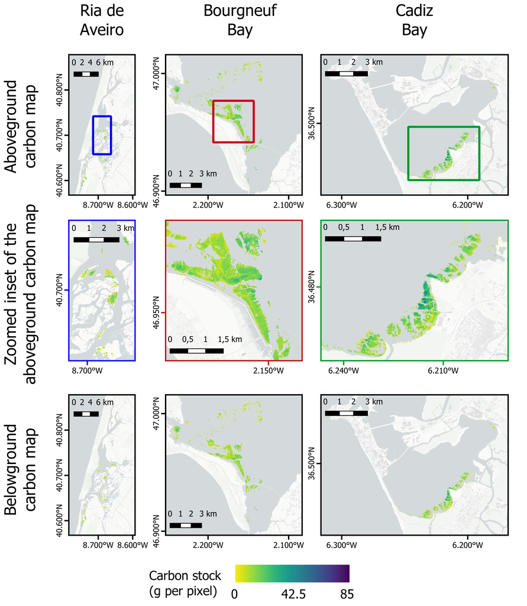

Figure 7: Sentinel-2-derived predicted carbon maps for the field campaign dates in 2025.

Table 1: Predicted cover values.

| Site | Date | Total intertidal area (ha) | Cumulative seagrass area (ha) | Mean Belowground biomass to aboveground biomass ratio | Total aboveground biomass (Mg DW) | Total belowground biomass (Mg DW) | Total aboveground carbon stock (Mg C) | Total belowground carbon stock (Mg C) |
| --- | --- | --- | --- | --- | --- | --- | --- | --- |
| Bourgneuf Bay | 25 August 2025 | 3258.59 | 233.07 | 0.96 | 195.64 | 186.95 | 59.84 | 52.82 |
| Ria de Aveiro | 15 July 2025 | 527.97 | 131.48 | 0.75 | 117.18 | 87.99 | 33.80 | 22.48 |
| Cadiz Bay | 14 June 2025 | 728.01 | 73.12 | 0.86 | 72.50 | 62.31 | 19.38 | 16.24 |
| Total |  | 4514.57 | 437.67 |  | 385.33 | 337.25 | 113.01 | 91.55 |

## 4 Discussion

Work in progress

## 5 Supplementary data

Table 2: Available data across the different field campaign.

| Site | Year | Radiometry | Aboveground biomass | Belowground biomass | Aboveground carbon | Belowground carbon | Source |
| --- | --- | --- | --- | --- | --- | --- | --- |
| Bourgneuf Bay | 2018 | 18 | 18 | 0 | 0 | 0 | Zoffoli et al. (2020) |
| Bourgneuf Bay | 2019 | 23 | 30 | 30 | 0 | 0 | Zoffoli et al. (2020) |
| Bourgneuf Bay | 2025 | 30 | 54 | 54 | 21 | 16 | Current study |
| Ria de Aveiro | 2025 | 23 | 85 | 85 | 35 | 34 | Current study |
| Cadiz Bay | 2025 | 24 | 24 | 24 | 15 | 15 | Current study |
| Total |  | 118 | 211 | 193 | 71 | 65 |  |

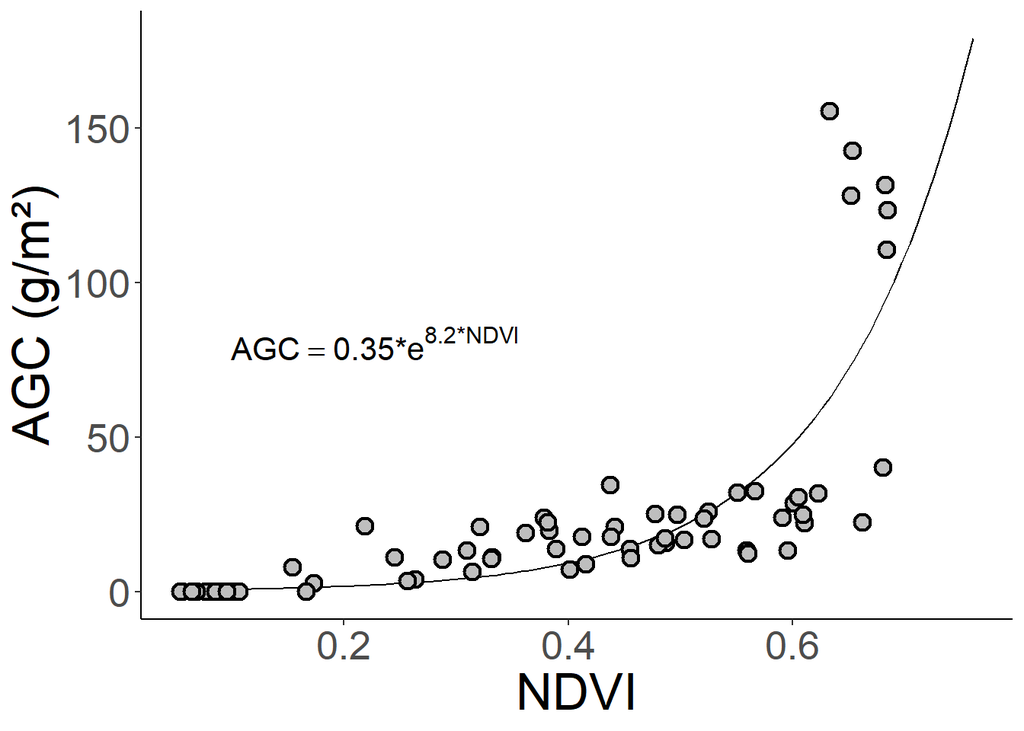

Figure 8: Relationship between the seagrass aboveground carbon (AGC) and the spectroradiometer-derived NDVI values.

## References

Barillé, Laurent, Anthony Le Bris, Philippe Goulletquer, Yoann Thomas, Philippe Glize, Frank Kane, Lynne Falconer, et al. 2020. “Biological, Socio-Economic, and Administrative Opportunities and Challenges to Moving Aquaculture Offshore for Small French Oyster-Farming Companies.” *Aquaculture* 521: 735045. https://doi.org/https://doi.org/10.1016/j.aquaculture.2020.735045.

Davies, Bede Ffinian Rowe, Simon Oiry, Philippe Rosa, Maria Laura Zoffoli, Ana I. Sousa, Oliver R. Thomas, Dan A. Smale, et al. 2024a. “Intertidal Seagrass Extent from Sentinel-2 Time-Series Show Distinct Trajectories in Western Europe.” *Remote Sensing of Environment* 312: 114340. https://doi.org/10.1016/j.rse.2024.114340.

Davies, Bede Ffinian Rowe, Simon Oiry, Philippe Rosa, Maria Laura Zoffoli, Ana I Sousa, Oliver R Thomas, Dan A Smale, et al. 2024b. “A Sentinel Watching over Inter-Tidal Seagrass Phenology Across Western Europe and North Africa.” *Communications Earth & Environment* 5 (1): 382.

Dias, João Miguel, Francisco Pereira, Ana Picado, Carina Lurdes Lopes, João Pedro Pinheiro, Sérgio Miguel Lopes, and Paulo Gabriel Pinho. 2021. “A Comprehensive Estuarine Hydrodynamics-Salinity Study: Impact of Morphologic Changes on Ria de Aveiro (Atlantic Coast of Portugal).” *Journal of Marine Science and Engineering* 9 (2). https://doi.org/https://doi.org/10.3390/jmse9020234.

*Sentinel-2 Spectral Response Functions* (version 3.2). 2023. European Space Agency.

signal developers. 2023. *signal: Signal Processing*. https://r-forge.r-project.org/projects/signal/.

Zarzuelo, Carmen, Alejandro López-Ruiz, Manuel Díez-Minguito, and Miguel Ortega-Sánchez. 2017. “Tidal and Subtidal Hydrodynamics and Energetics in a Constricted Estuary.” *Estuarine, Coastal and Shelf Science* 185: 55–68. https://doi.org/https://doi.org/10.1016/j.ecss.2016.11.020.

Zoffoli, Maria Laura, Pierre Gernez, Philippe Rosa, Anthony Le Bris, Vittorio E Brando, Anne-Laure Barillé, Nicolas Harin, et al. 2020. “Sentinel-2 Remote Sensing of *Zostera Noltei*-Dominated Intertidal Seagrass Meadows.” *Remote Sensing of Environment* 251: 112020. https://doi.org/https://doi.org/10.1016/j.rse.2020.112020.